# Data Wrangling With R - Week 4

Nitin

November 8, 2016

# Synopsis

This file encompasses the Week 4 Homework of the Data Wrangling with R class. This week concentrates on exploring the gapminder dataset availble on CRAN

```r
#Load relevant libraries
library(gapminder)
library(dplyr)
library(ggplot2)
library(ggthemes)
```

# Source Code

# Data Description

### Basic Data Structure and Summary Statistics

The data set includes 3313 observations of 6 variables  
The variables include country, continent, year, lifeExp, pop and gdpPercap

```r
summary(gapminder_unfiltered)
```

```
##            country        continent         year         lifeExp
##  Czech Republic:  58   Africa  : 637   Min.   :1950   Min.   :23.60
##  Denmark       :  58   Americas: 470   1st Qu.:1967   1st Qu.:58.33
##  Finland       :  58   Asia    : 578   Median :1982   Median :69.61
##  Iceland       :  58   Europe  :1302   Mean   :1980   Mean   :65.24
##  Japan         :  58   FSU     : 139   3rd Qu.:1996   3rd Qu.:73.66
##  Netherlands   :  58   Oceania : 187   Max.   :2007   Max.   :82.67
##  (Other)       :2965
##       pop              gdpPercap
##  Min.   :5.941e+04   Min.   :   241.2
##  1st Qu.:2.680e+06   1st Qu.:  2505.3
##  Median :7.560e+06   Median :  7825.8
##  Mean   :3.177e+07   Mean   : 11313.8
##  3rd Qu.:1.961e+07   3rd Qu.: 17355.8
##  Max.   :1.319e+09   Max.   :113523.1
##
```

```r
#psych::describe(gapminder_unfiltered)
#Hmisch::describe(gapminder_unfiltered)
```

## Exploratory Data Analysis

### What is the distribution of GDP per capita across all countries?

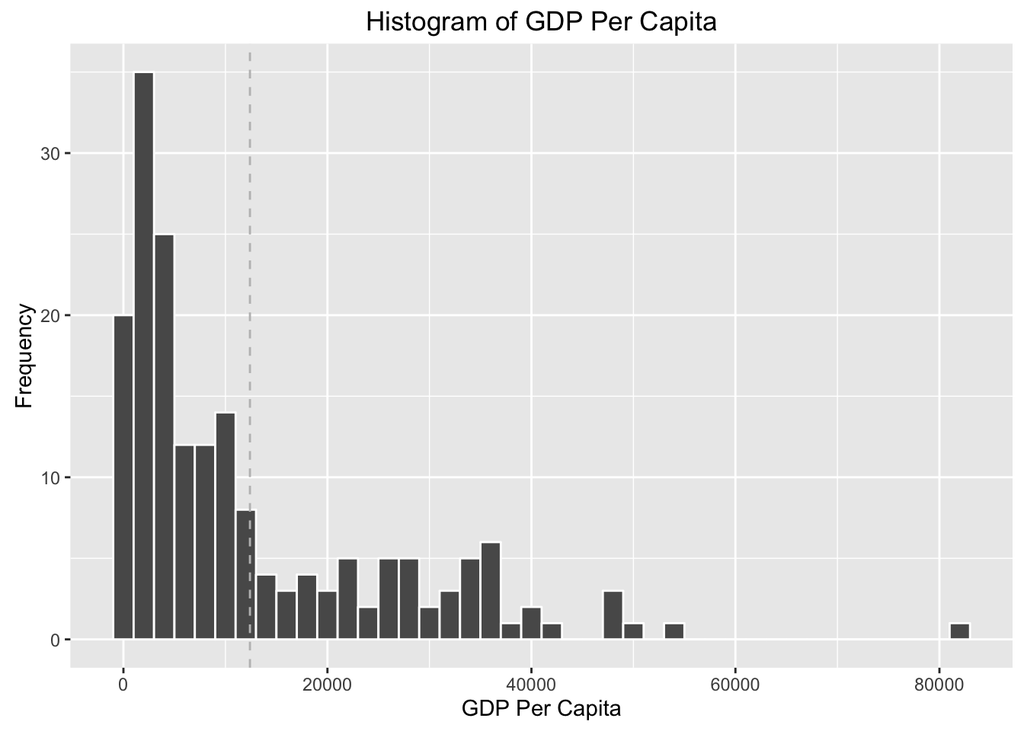

```r
gapminder_unfiltered %>%
  filter(year == 2007) %>%
  ggplot(aes(gdpPercap))+geom_histogram(binwidth   = 2000, color = "white") +
  labs(title = "Histogram of GDP Per Capita") +
  labs(x="GDP Per Capita" , y = "Frequency") +
  geom_vline(aes(xintercept=mean(gdpPercap)),
            color="grey", linetype="dashed", size=0.5)
```

We observe that the GDP Per Capita is heavily right skewed.

### How do the distributions differ across the different continents?

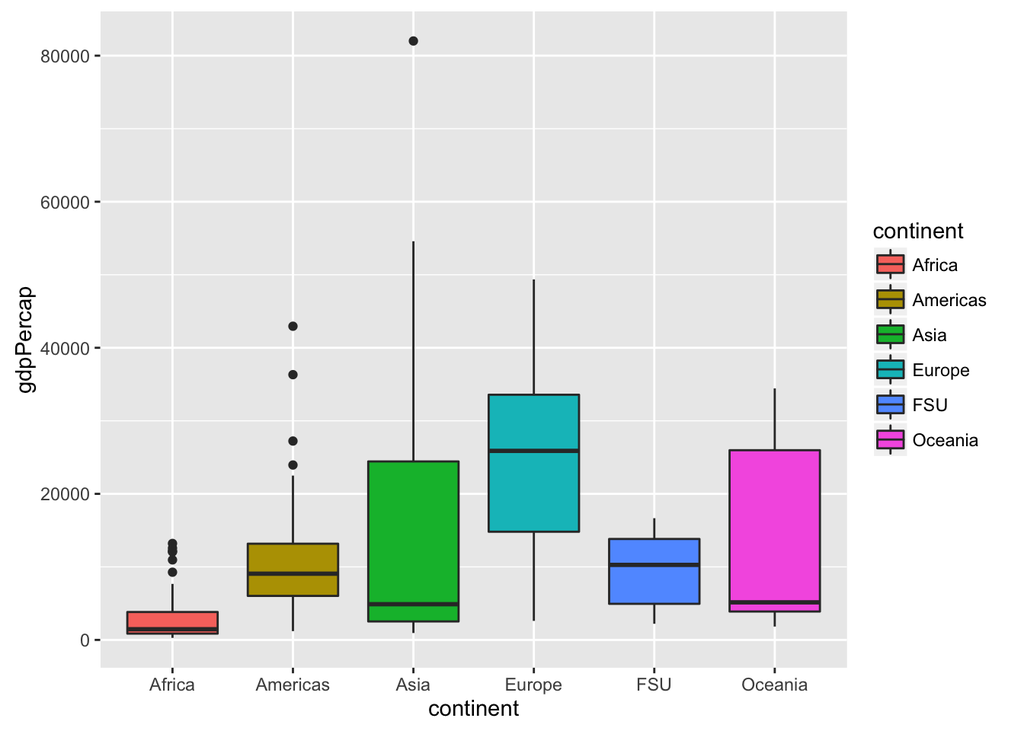

```r
gapminder_unfiltered %>%
  filter(year == 2007) %>%
  ggplot(aes(x = continent, y = gdpPercap, fill = continent))+geom_boxplot()
```

We observe that the distributions are quite different across continents with Asia showcasing the maximum range and Africa with the least range.  
Europe seems to have the highes mean while Asia showcases the largest GDP Per capita

### What are the top 10 countries with the largest GDP per capita?

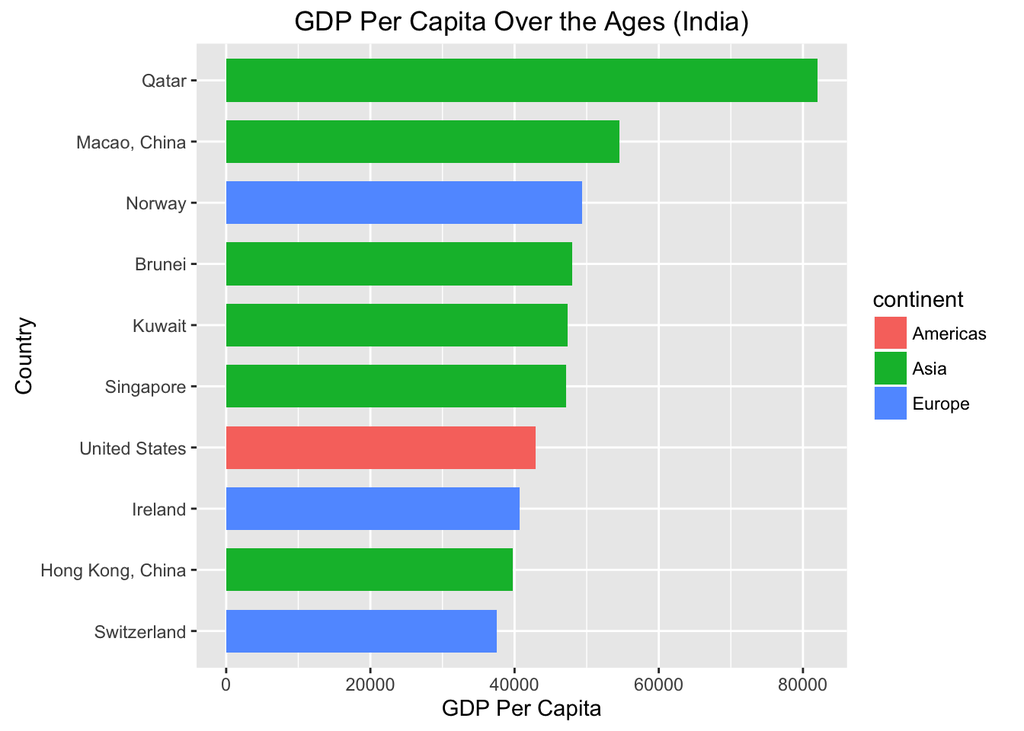

```r
gapminder_unfiltered %>%
  filter(year == 2007) %>%
  arrange(desc(gdpPercap)) %>%
  top_n(n = 10, gdpPercap) %>%
  ggplot(aes(x = reorder(country, gdpPercap), y = gdpPercap, fill = continent)) + geom_bar(stat = "identity", width = 0.7) + coord_flip() +
labs(title = "GDP Per Capita Over the Ages (India)") +
  labs(x = "Country", y = "GDP Per Capita")
```

We observe that primarily Asian countries represent the top 10 countries with highest GDP Per capita

### Plot the GDP per capita for your country of origin for all years available

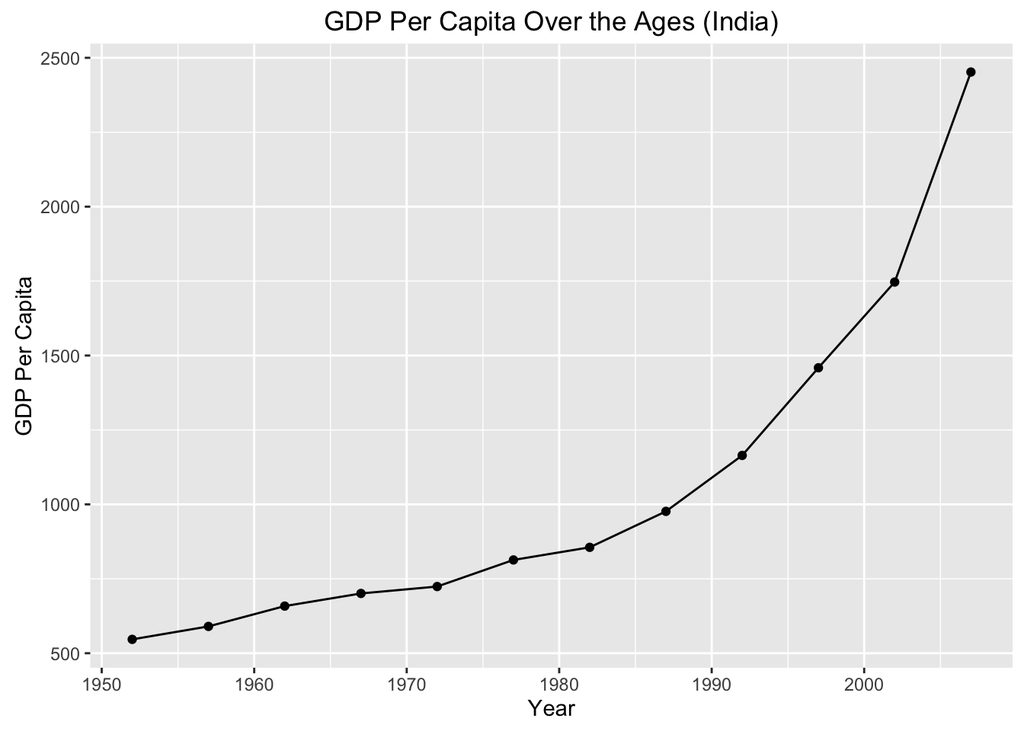

```r
gapminder_unfiltered %>%
  filter(country == "India") %>%
  ggplot(aes(x = year, y = gdpPercap)) +
  geom_line() +
  labs(title = "GDP Per Capita Over the Ages (India)") +
  labs(x = "Year", y = "GDP Per Capita") +
  geom_point()
```

We observe an exponential growth over the past few decades

### What was the percent growth (or decline) in GDP per capita in 2007?

```r
growth_rate <- gapminder_unfiltered %>%
  filter(country == "India") %>% mutate(Change = (gdpPercap - lag(gdpPercap))/(lag(gdpPercap)) * 100) %>%
  select(Country = country,Year = year, Change)
growth_rate
```

```
## # A tibble: 12 x 3
##    Country  Year    Change
##     <fctr> <int>     <dbl>
## 1    India  1952        NA
## 2    India  1957  7.958100
## 3    India  1962 11.572539
## 4    India  1967  6.443935
## 5    India  1972  3.319477
## 6    India  1977 12.334362
## 7    India  1982  5.211394
## 8    India  1987 14.115439
## 9    India  1992 19.241341
## 10   India  1997 25.284173
## 11   India  2002 19.738728
## 12   India  2007 40.385464
```

We observe a growth of 40.38%

### What has been the historical growth (or decline) in GDP per capita for your country?

```r
mean(growth_rate$Change, na.rm = TRUE)
```

```
## [1] 15.055
```

Historically India has been growing at 15%